# Lab 2

Author

Alexa Hildebrand

## 0: Import Dataset and Declare Package Dependencies

```python
import pandas as pd
import plotnine
from plotnine import ggplot, aes, geom_boxplot, stat_summary, geom_text, geom_point, stat_boxplot, geom_bar,facet_wrap, labs, scale_y_continuous
from plotnine import scale_color_manual, scale_fill_manual, theme, geom_line, geom_path, geom_point, ggtitle, geom_text, annotate, scale_size_area, scale_y_log10
```

```python
avocados = pd.read_csv("C:/Users/alexa/OneDrive/Desktop/avocado-updated-2020.csv")
avocados
```

|  | date | average_price | total_volume | 4046 | 4225 | 4770 | total_bags | small_bags | large_bags | xlarge_bags | type | year | geography |
| --- | --- | --- | --- | --- | --- | --- | --- | --- | --- | --- | --- | --- | --- |
| 0 | 2015-01-04 | 1.22 | 40873.28 | 2819.50 | 28287.42 | 49.90 | 9716.46 | 9186.93 | 529.53 | 0.00 | conventional | 2015 | Albany |
| 1 | 2015-01-04 | 1.79 | 1373.95 | 57.42 | 153.88 | 0.00 | 1162.65 | 1162.65 | 0.00 | 0.00 | organic | 2015 | Albany |
| 2 | 2015-01-04 | 1.00 | 435021.49 | 364302.39 | 23821.16 | 82.15 | 46815.79 | 16707.15 | 30108.64 | 0.00 | conventional | 2015 | Atlanta |
| 3 | 2015-01-04 | 1.76 | 3846.69 | 1500.15 | 938.35 | 0.00 | 1408.19 | 1071.35 | 336.84 | 0.00 | organic | 2015 | Atlanta |
| 4 | 2015-01-04 | 1.08 | 788025.06 | 53987.31 | 552906.04 | 39995.03 | 141136.68 | 137146.07 | 3990.61 | 0.00 | conventional | 2015 | Baltimore/Washington |
| ... | ... | ... | ... | ... | ... | ... | ... | ... | ... | ... | ... | ... | ... |
| 33040 | 2020-11-29 | 1.47 | 1583056.27 | 67544.48 | 97996.46 | 2617.17 | 1414878.10 | 906711.52 | 480191.83 | 27974.75 | organic | 2020 | Total U.S. |
| 33041 | 2020-11-29 | 0.91 | 5811114.22 | 1352877.53 | 589061.83 | 19741.90 | 3790665.29 | 2197611.02 | 1531530.14 | 61524.13 | conventional | 2020 | West |
| 33042 | 2020-11-29 | 1.48 | 289961.27 | 13273.75 | 19341.09 | 636.51 | 256709.92 | 122606.21 | 134103.71 | 0.00 | organic | 2020 | West |
| 33043 | 2020-11-29 | 0.67 | 822818.75 | 234688.01 | 80205.15 | 10543.63 | 497381.96 | 285764.11 | 210808.02 | 809.83 | conventional | 2020 | West Tex/New Mexico |
| 33044 | 2020-11-29 | 1.35 | 24106.58 | 1236.96 | 617.80 | 1564.98 | 20686.84 | 17824.52 | 2862.32 | 0.00 | organic | 2020 | West Tex/New Mexico |

33045 rows × 13 columns

## 1: Briefly Describe the Dataset, what information does it contain

This dataset is based on avocado prices and sales volume in different geographies within the United States on specific dates from 2015-2020. Some of the types of geographies included are state, region, metro, country, and city. It specifically contains information about Hass avocados of 3 different varieties: 4046 = small Hass (Total number of avocados with PLU 4046 sold), 4225 = large hass, 4770 = extra large hass.

The columns included are:

date: date of observation

average_price: average price of single avocado on that day of that type

total_volume: total number of avocados sold of any variety

4046: total number of avocados with PLU 4046(small Hass) sold

4225: total number of large Hass avocados sold

4770: total number of extra large Hass avocados sold

total_bags: number of bags sold

small_bags: number of small bags of avocados sold

large_bags: number of large bags of avocados sold

xlarge_bags: number of xlarge bags of avocados sold

type: type of avocado - either conventional or organic

year: year of observation

## 2: Clean the data in any way you see fit

```python
#define different geographies
state = ['California', 'South Carolina', 'New York']
region = ['Great Lakes', 'Midsouth', 'Northeast', 'Northern New England', 'Plains', 'South Central', 'Southeast', 'West']
metro = ['Baltimore/Washington', 'Buffalo/Rochester', 'Cincinnati/Dayton', 'Dallas/Ft. Worth', 'Harrisburg/Scranton',
         'Hartford/Springfield', 'Miami/Ft. Lauderdale', 'New Orleans/Mobile', 'Phoenix/Tucson', 'Raleigh/Greensboro',
         'Richmond/Norfolk','West Tex/New Mexico']
city = ['Atlanta','Boise','Boston','Charlotte','Chicago','Columbus','Denver','Detroit','Grand Rapids','Houston','Indianapolis','Jacksonville','Las Vegas',
        'Los Angeles','Louisville','Nashville','Orlando','Philadelphia','Pittsburgh','Portland','Roanoke','Sacramento','San Diego','San Francisco',
        'Seattle','Spokane','St. Louis','Syracuse','Tampa']
country = ['Total U.S.']

#create data set for state
avocado_state = avocados[avocados['geography'].isin(state)]
avocado_state

#create data set for region
avocado_region = avocados[avocados['geography'].isin(region)]
avocado_region

#create data set for metro
avocado_metro = avocados[avocados['geography'].isin(metro)]
avocado_metro

#create data set for country
avocado_country = avocados[avocados['geography'].isin(country)]
avocado_country

#create data set for city
avocado_city = avocados[avocados['geography'].isin(city)]
avocado_city

#change the name of columns
avocado_state = avocado_state.rename(columns =
                     {'4046':'Small_Hass_Sold',
                     '4225':'Large_Hass_Sold',
                     '4770':'Extra_Large_Hass_Sold'})

#change the name of columns
avocado_region = avocado_region.rename(columns =
                     {'4046':'Small_Hass_Sold',
                     '4225':'Large_Hass_Sold',
                     '4770':'Extra_Large_Hass_Sold'})

#change the name of columns
avocado_metro = avocado_metro.rename(columns =
                     {'4046':'Small_Hass_Sold',
                     '4225':'Large_Hass_Sold',
                     '4770':'Extra_Large_Hass_Sold'})
#change the name of columns
avocado_country = avocado_country.rename(columns =
                     {'4046':'Small_Hass_Sold',
                     '4225':'Large_Hass_Sold',
                     '4770':'Extra_Large_Hass_Sold'})

#change the name of columns
avocado_city = avocado_city.rename(columns =
                     {'4046':'Small_Hass_Sold',
                     '4225':'Large_Hass_Sold',
                     '4770':'Extra_Large_Hass_Sold'})

#change the name of columns
avocado_clean = avocados.rename(columns =
                     {'4046':'Small_Hass_Sold',
                     '4225':'Large_Hass_Sold',
                     '4770':'Extra_Large_Hass_Sold'})
```

## 3. Which major geographical region sold the most total organic, small Hass avocados in 2017?

```python
avocado_region
```

|  | date | average_price | total_volume | Small_Hass_Sold | Large_Hass_Sold | Extra_Large_Hass_Sold | total_bags | small_bags | large_bags | xlarge_bags | type | year | geography |
| --- | --- | --- | --- | --- | --- | --- | --- | --- | --- | --- | --- | --- | --- |
| 30 | 2015-01-04 | 1.02 | 3382800.12 | 467259.47 | 2059657.71 | 318102.38 | 537780.56 | 412779.64 | 111072.91 | 13928.01 | conventional | 2015 | Great Lakes |
| 31 | 2015-01-04 | 1.54 | 61615.10 | 3633.93 | 42963.06 | 0.00 | 15018.11 | 9763.55 | 5254.56 | 0.00 | organic | 2015 | Great Lakes |
| 50 | 2015-01-04 | 1.10 | 2578275.12 | 575245.44 | 1311502.53 | 181058.65 | 510468.50 | 429166.89 | 80986.81 | 314.80 | conventional | 2015 | Midsouth |
| 51 | 2015-01-04 | 1.56 | 58065.35 | 10049.66 | 25228.37 | 3672.89 | 19114.43 | 17280.89 | 1833.54 | 0.00 | organic | 2015 | Midsouth |
| 58 | 2015-01-04 | 1.09 | 3759282.62 | 126640.65 | 2860709.93 | 7580.38 | 764351.66 | 669970.50 | 94381.16 | 0.00 | conventional | 2015 | Northeast |
| ... | ... | ... | ... | ... | ... | ... | ... | ... | ... | ... | ... | ... | ... |
| 33028 | 2020-11-29 | 1.21 | 158664.34 | 11229.49 | 1403.69 | 1671.19 | 144359.97 | 97499.68 | 46860.29 | 0.00 | organic | 2020 | South Central |
| 33029 | 2020-11-29 | 0.70 | 5074329.31 | 2288488.28 | 169801.18 | 1876.23 | 2614148.83 | 2187694.31 | 408444.24 | 18010.28 | conventional | 2020 | Southeast |
| 33030 | 2020-11-29 | 1.23 | 141358.02 | 1149.87 | 5916.04 | 47.60 | 134244.51 | 79452.47 | 37802.46 | 16989.58 | organic | 2020 | Southeast |
| 33041 | 2020-11-29 | 0.91 | 5811114.22 | 1352877.53 | 589061.83 | 19741.90 | 3790665.29 | 2197611.02 | 1531530.14 | 61524.13 | conventional | 2020 | West |
| 33042 | 2020-11-29 | 1.48 | 289961.27 | 13273.75 | 19341.09 | 636.51 | 256709.92 | 122606.21 | 134103.71 | 0.00 | organic | 2020 | West |

4896 rows × 13 columns

```python
#filter to only year 2017
year_2017 = avocado_region[avocado_region['year'] == 2017]

#filter to only type organic
region_2017 = year_2017[year_2017['type'] == 'organic']

#add up all the small Hass avocados sold that are organic in 2017, grouping by each region
region_2017 = region_2017[["Small_Hass_Sold", "geography"]].groupby("geography").sum()

#reset index so geogrophy is a column
region_2017 = region_2017.reset_index()

region_2017 = region_2017.rename(columns = {'Small_Hass_Sold':'Total_Small_Hass_Sold'})

#sort values to find largest amount sold
region_2017 = region_2017.sort_values(by = ["Total_Small_Hass_Sold"], ascending=False)
region_2017
```

|  | geography | Total_Small_Hass_Sold |
| --- | --- | --- |
| 7 | West | 1870206.29 |
| 5 | South Central | 1717104.19 |
| 2 | Northeast | 925832.36 |
| 6 | Southeast | 285124.34 |
| 0 | Great Lakes | 202487.68 |
| 1 | Midsouth | 186395.50 |
| 4 | Plains | 168583.40 |
| 3 | Northern New England | 1249.48 |

The West region sold the most total organic, small Hass avocadoes in 2017 with 1,870,206.29 (based on the table above).

## 4. Split the date variable into month, day, and year variables. In which month is the highest average volume of avocado sales?

```python
#split column to Year, Month, Day where there is a -
avocado_clean[['Year','Month', 'Day']] = avocado_clean.date.str.split("-",expand=True)
avocado_clean
```

|  | date | average_price | total_volume | Small_Hass_Sold | Large_Hass_Sold | Extra_Large_Hass_Sold | total_bags | small_bags | large_bags | xlarge_bags | type | year | geography | Year | Month | Day |
| --- | --- | --- | --- | --- | --- | --- | --- | --- | --- | --- | --- | --- | --- | --- | --- | --- |
| 0 | 2015-01-04 | 1.22 | 40873.28 | 2819.50 | 28287.42 | 49.90 | 9716.46 | 9186.93 | 529.53 | 0.00 | conventional | 2015 | Albany | 2015 | 01 | 04 |
| 1 | 2015-01-04 | 1.79 | 1373.95 | 57.42 | 153.88 | 0.00 | 1162.65 | 1162.65 | 0.00 | 0.00 | organic | 2015 | Albany | 2015 | 01 | 04 |
| 2 | 2015-01-04 | 1.00 | 435021.49 | 364302.39 | 23821.16 | 82.15 | 46815.79 | 16707.15 | 30108.64 | 0.00 | conventional | 2015 | Atlanta | 2015 | 01 | 04 |
| 3 | 2015-01-04 | 1.76 | 3846.69 | 1500.15 | 938.35 | 0.00 | 1408.19 | 1071.35 | 336.84 | 0.00 | organic | 2015 | Atlanta | 2015 | 01 | 04 |
| 4 | 2015-01-04 | 1.08 | 788025.06 | 53987.31 | 552906.04 | 39995.03 | 141136.68 | 137146.07 | 3990.61 | 0.00 | conventional | 2015 | Baltimore/Washington | 2015 | 01 | 04 |
| ... | ... | ... | ... | ... | ... | ... | ... | ... | ... | ... | ... | ... | ... | ... | ... | ... |
| 33040 | 2020-11-29 | 1.47 | 1583056.27 | 67544.48 | 97996.46 | 2617.17 | 1414878.10 | 906711.52 | 480191.83 | 27974.75 | organic | 2020 | Total U.S. | 2020 | 11 | 29 |
| 33041 | 2020-11-29 | 0.91 | 5811114.22 | 1352877.53 | 589061.83 | 19741.90 | 3790665.29 | 2197611.02 | 1531530.14 | 61524.13 | conventional | 2020 | West | 2020 | 11 | 29 |
| 33042 | 2020-11-29 | 1.48 | 289961.27 | 13273.75 | 19341.09 | 636.51 | 256709.92 | 122606.21 | 134103.71 | 0.00 | organic | 2020 | West | 2020 | 11 | 29 |
| 33043 | 2020-11-29 | 0.67 | 822818.75 | 234688.01 | 80205.15 | 10543.63 | 497381.96 | 285764.11 | 210808.02 | 809.83 | conventional | 2020 | West Tex/New Mexico | 2020 | 11 | 29 |
| 33044 | 2020-11-29 | 1.35 | 24106.58 | 1236.96 | 617.80 | 1564.98 | 20686.84 | 17824.52 | 2862.32 | 0.00 | organic | 2020 | West Tex/New Mexico | 2020 | 11 | 29 |

33045 rows × 16 columns

```python
#take the average total volume of avocado sales by Month
month_sales= avocado_clean[["total_volume", "Month"]].groupby("Month").mean()

#reset index so month is a column
month_sales = month_sales.reset_index()

month_sales = month_sales.rename(columns = {'total_volume':'Avg_Small_Hass_Sold'})

#sort values to find the largest total volume
month_sales = month_sales.sort_values(by = ["Avg_Small_Hass_Sold"], ascending=False)
month_sales
```

|  | Month | Avg_Small_Hass_Sold |
| --- | --- | --- |
| 4 | 05 | 1.123632e+06 |
| 1 | 02 | 1.095374e+06 |
| 5 | 06 | 1.051247e+06 |
| 3 | 04 | 1.016582e+06 |
| 2 | 03 | 9.957150e+05 |
| 0 | 01 | 9.853122e+05 |
| 6 | 07 | 9.832681e+05 |
| 7 | 08 | 9.499249e+05 |
| 8 | 09 | 9.064773e+05 |
| 9 | 10 | 8.446863e+05 |
| 10 | 11 | 8.223470e+05 |
| 11 | 12 | 8.076695e+05 |

May (Month 5) had the highest average total volume of avocado sales with 1,123,632 (based on table above).

## 5. Which metro area geographical regions sold the most total avocados? Plot side-by-side box-plots of the total volume for only the five metro geographical regions with the highest averages for the total_volume variable.

```python
#from metro data set, add up the total volume of avocados sold by each metro area
metro_total = avocado_metro[["total_volume", "geography"]].groupby("geography").sum()

#sort values to find largest total volume
metro_total = metro_total.sort_values(by = ["total_volume"], ascending=False)

#reset index so geography is a column
metro_total = metro_total.reset_index()

#select the top 5 rows with highest volume sold
metro_total_5 = metro_total[0:5]
metro_total_5
```

|  | geography | total_volume |
| --- | --- | --- |
| 0 | Dallas/Ft. Worth | 4.362042e+08 |
| 1 | Phoenix/Tucson | 3.825234e+08 |
| 2 | West Tex/New Mexico | 2.806116e+08 |
| 3 | Baltimore/Washington | 2.767646e+08 |
| 4 | Miami/Ft. Lauderdale | 2.317448e+08 |

```python
#from metro dataset, average total volume of avocados sold by each metro area
metro_avg = avocado_metro[["total_volume", "geography"]].groupby("geography").mean()

#sort values to find largest average total volume sold
metro_avg = metro_avg.sort_values(by = ["total_volume"], ascending=False)

#reset index so geography is a column
metro_avg = metro_avg.reset_index()
#metro_avg = metro_avg.rename(columns = {'total_volume':'avg_total_volume'})

#choose type 5 regions with highest averages of total_volume
metro_avg_5 = metro_avg[0:5]
metro_avg_5
```

|  | geography | total_volume |
| --- | --- | --- |
| 0 | Dallas/Ft. Worth | 712751.896814 |
| 1 | Phoenix/Tucson | 625038.257500 |
| 2 | West Tex/New Mexico | 460774.328900 |
| 3 | Baltimore/Washington | 452229.794281 |
| 4 | Miami/Ft. Lauderdale | 378668.053399 |

The metro areas that sold the most total avocados (and have highest average) are Dallas/Ft. Worth, Phoenix/Tucson, West Tex/New Mexico, Baltimore/Washington, Miami/Ft. Lauderdale. Dallas/Ft. Worth sold the highest overall total avocados with 436,204,200.

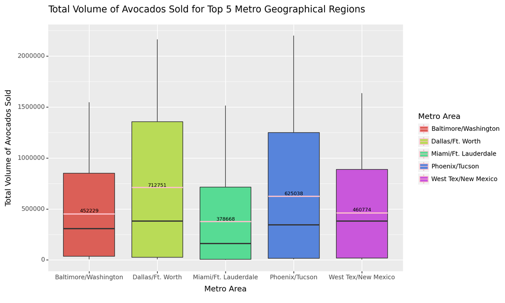

```
<Figure Size: (1000 x 600)>
```

```python
#choose the individual values for the five metro geographical regions with highest average total_volume
filtered_metro = avocado_metro[avocado_metro['geography'].isin(metro_avg_5['geography'])]

#pink line represents the average

(ggplot(filtered_metro, aes(x='geography', y = 'total_volume', fill = 'geography'))
       +geom_boxplot()
       +stat_boxplot(data = metro_avg_5, color = "pink")
       +theme(figure_size=(10,6))
       +labs(x="Metro Area")
       +labs(y="Total Volume of Avocados Sold")
       +labs(fill = "Metro Area")
       +ggtitle("Total Volume of Avocados Sold for Top 5 Metro Geographical Regions")
       +annotate("text",label ="452229", x = "Baltimore/Washington", y = 480000, size = 7)
       +annotate("text",label ="712751", x = "Dallas/Ft. Worth", y = 730000, size = 7)
       +annotate("text",label ="378668", x = "Miami/Ft. Lauderdale", y = 400000, size = 7)
       +annotate("text",label ="625038", x = "Phoenix/Tucson", y = 650000, size = 7)
       +annotate("text",label ="460774", x = "West Tex/New Mexico", y = 490000, size = 7)
)
```

References: https://www.geeksforgeeks.org/split-a-text-column-into-two-columns-in-pandas-dataframe/; https://plotnine.readthedocs.io/en/stable/generated/plotnine.stats.stat_boxplot.html

## 6. From your cleaned data set, create a data set with only these California regions and answer the following questions about these California regions only.

```python
#define the four California regions
california = ["Los Angeles", "San Diego", "Sacramento", "San Francisco"]

#only include geographies in california list
avo_cali = avocado_clean['geography'].isin(california)
avocado_cali = avocado_clean[avo_cali]
avocado_cali
```

|  | date | average_price | total_volume | Small_Hass_Sold | Large_Hass_Sold | Extra_Large_Hass_Sold | total_bags | small_bags | large_bags | xlarge_bags | type | year | geography | Year | Month | Day |
| --- | --- | --- | --- | --- | --- | --- | --- | --- | --- | --- | --- | --- | --- | --- | --- | --- |
| 44 | 2015-01-04 | 0.85 | 2682159.95 | 1837999.65 | 524430.47 | 64225.78 | 255504.05 | 215571.80 | 36981.72 | 2950.53 | conventional | 2015 | Los Angeles | 2015 | 01 | 04 |
| 45 | 2015-01-04 | 1.25 | 54495.54 | 47721.51 | 1723.40 | 0.00 | 5050.63 | 5050.63 | 0.00 | 0.00 | organic | 2015 | Los Angeles | 2015 | 01 | 04 |
| 80 | 2015-01-04 | 1.05 | 430138.88 | 110693.69 | 270107.61 | 9737.50 | 39600.08 | 39600.08 | 0.00 | 0.00 | conventional | 2015 | Sacramento | 2015 | 01 | 04 |
| 81 | 2015-01-04 | 1.33 | 9213.49 | 3727.52 | 4327.52 | 0.00 | 1158.45 | 1158.45 | 0.00 | 0.00 | organic | 2015 | Sacramento | 2015 | 01 | 04 |
| 82 | 2015-01-04 | 0.94 | 461607.33 | 244152.26 | 165299.33 | 15302.75 | 36852.99 | 30884.29 | 5595.00 | 373.70 | conventional | 2015 | San Diego | 2015 | 01 | 04 |
| ... | ... | ... | ... | ... | ... | ... | ... | ... | ... | ... | ... | ... | ... | ... | ... | ... |
| 33018 | 2020-11-29 | 1.43 | 23531.38 | 3303.69 | 2057.03 | 0.00 | 18170.66 | 18144.54 | 26.12 | 0.00 | organic | 2020 | Sacramento | 2020 | 11 | 29 |
| 33019 | 2020-11-29 | 1.12 | 469356.72 | 104509.99 | 19988.45 | 7210.47 | 337647.81 | 189341.36 | 127701.64 | 20604.81 | conventional | 2020 | San Diego | 2020 | 11 | 29 |
| 33020 | 2020-11-29 | 1.95 | 25799.95 | 894.63 | 838.11 | 0.00 | 24067.21 | 9691.46 | 14375.75 | 0.00 | organic | 2020 | San Diego | 2020 | 11 | 29 |
| 33021 | 2020-11-29 | 1.50 | 644141.37 | 128555.43 | 136718.24 | 5597.21 | 373270.49 | 159276.65 | 207760.32 | 6233.52 | conventional | 2020 | San Francisco | 2020 | 11 | 29 |
| 33022 | 2020-11-29 | 1.87 | 59527.02 | 2815.23 | 4542.30 | 0.00 | 52169.49 | 52034.33 | 135.16 | 0.00 | organic | 2020 | San Francisco | 2020 | 11 | 29 |

2448 rows × 16 columns

## 7. In which California regions is the price of organic versus conventional avocados most different? Support your answer with a few summary statistics AND a visualization.

```python
#average price by each california region and type
avocado_type = avocado_cali[["average_price", "type", "geography"]].groupby(['geography', 'type']).mean()
avocado_type = avocado_type.reset_index()
avocado_type
```

|  | geography | type | average_price |
| --- | --- | --- | --- |
| 0 | Los Angeles | conventional | 1.047124 |
| 1 | Los Angeles | organic | 1.574902 |
| 2 | Sacramento | conventional | 1.295359 |
| 3 | Sacramento | organic | 1.873856 |
| 4 | San Diego | conventional | 1.113856 |
| 5 | San Diego | organic | 1.798366 |
| 6 | San Francisco | conventional | 1.400490 |
| 7 | San Francisco | organic | 2.119444 |

```python
#pivot from long to wide, type now become columns and values are avergae price for each type by geography
wide_avocado = avocado_type.pivot(index = "geography", columns = "type", values = "average_price")
wide_avocado = wide_avocado.reset_index()
wide_avocado
```

| type | geography | conventional | organic |
| --- | --- | --- | --- |
| 0 | Los Angeles | 1.047124 | 1.574902 |
| 1 | Sacramento | 1.295359 | 1.873856 |
| 2 | San Diego | 1.113856 | 1.798366 |
| 3 | San Francisco | 1.400490 | 2.119444 |

```python
#find difference in average price
wide_avocado["price_diff"] = wide_avocado["organic"] - wide_avocado["conventional"]

#find which California region had largest price difference between organic and conventional
wide_avocado = wide_avocado.sort_values(by ="price_diff", ascending = False)
wide_avocado
```

| type | geography | conventional | organic | price_diff |
| --- | --- | --- | --- | --- |
| 3 | San Francisco | 1.400490 | 2.119444 | 0.718954 |
| 2 | San Diego | 1.113856 | 1.798366 | 0.684510 |
| 1 | Sacramento | 1.295359 | 1.873856 | 0.578497 |
| 0 | Los Angeles | 1.047124 | 1.574902 | 0.527778 |

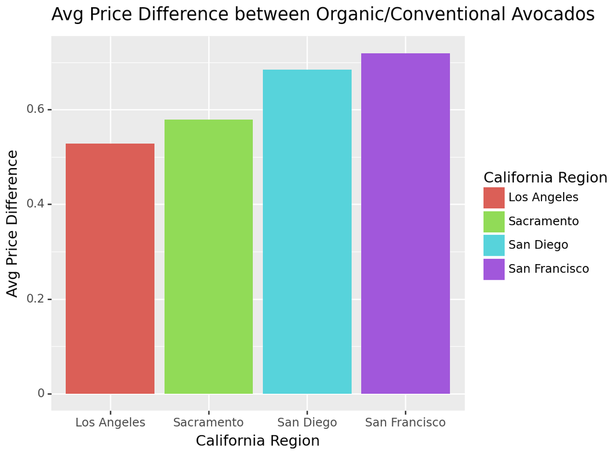

```
<Figure Size: (640 x 480)>
```

```python
(ggplot(wide_avocado, aes(x='geography', y='price_diff', fill='geography'))
+geom_bar(stat='identity')
+labs(x="California Region")
+labs(y="Avg Price Difference")
+labs(fill = "California Region")
+ggtitle("Avg Price Difference between Organic/Conventional Avocados"))
```

Based on difference in average price, San Francisco has the biggest average price difference between organic and conventional avocados in the California regions.

```python
#range = min-max
avocado_min = avocado_cali[["average_price", "type", "geography"]].groupby(['geography', 'type']).min()
avocado_min = avocado_min.reset_index()
avocado_max = avocado_cali[["average_price", "type", "geography"]].groupby(['geography', 'type']).max()
avocado_max = avocado_max.reset_index()

#find the range
avocado_range = avocado_max.merge(avocado_min, on=["geography", "type"])
avocado_range["range"] = avocado_range['average_price_x'] - avocado_range['average_price_y']
avocado_range


#make it wide
wide_avocado_range = avocado_range.pivot(index = "geography", columns = "type", values = "range")
wide_avocado_range = wide_avocado_range.reset_index()
wide_avocado_range

#differences in range
wide_avocado_range["diff_range"] = wide_avocado_range['organic'] - wide_avocado_range['conventional']
wide_avocado_range = wide_avocado_range.sort_values(by="diff_range", ascending = False)
wide_avocado_range
```

| type | geography | conventional | organic | diff_range |
| --- | --- | --- | --- | --- |
| 3 | San Francisco | 1.36 | 2.19 | 0.83 |
| 1 | Sacramento | 1.03 | 1.69 | 0.66 |
| 2 | San Diego | 1.22 | 1.73 | 0.51 |
| 0 | Los Angeles | 1.27 | 1.48 | 0.21 |

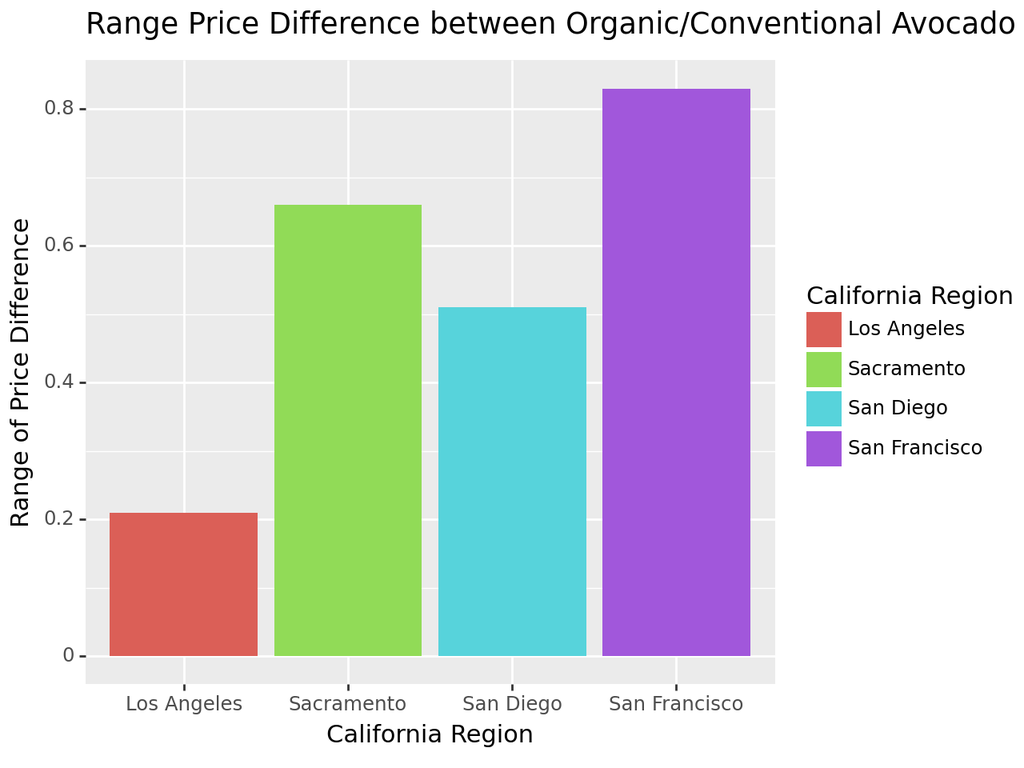

```
<Figure Size: (640 x 480)>
```

```python
(ggplot(wide_avocado_range, aes(x='geography', y='diff_range', fill='geography'))
+geom_bar(stat='identity')
+labs(x="California Region")
+labs(y="Range of Price Difference")
+labs(fill = "California Region")
+ggtitle("Range Price Difference between Organic/Conventional Avocado"))
```

Based on range of price difference, San Francisco has the biggest range in price difference between organic and conventional avocados in the California regions.

```python
avocado_cali
```

|  | date | average_price | total_volume | Small_Hass_Sold | Large_Hass_Sold | Extra_Large_Hass_Sold | total_bags | small_bags | large_bags | xlarge_bags | type | year | geography | Year | Month | Day |
| --- | --- | --- | --- | --- | --- | --- | --- | --- | --- | --- | --- | --- | --- | --- | --- | --- |
| 44 | 2015-01-04 | 0.85 | 2682159.95 | 1837999.65 | 524430.47 | 64225.78 | 255504.05 | 215571.80 | 36981.72 | 2950.53 | conventional | 2015 | Los Angeles | 2015 | 01 | 04 |
| 45 | 2015-01-04 | 1.25 | 54495.54 | 47721.51 | 1723.40 | 0.00 | 5050.63 | 5050.63 | 0.00 | 0.00 | organic | 2015 | Los Angeles | 2015 | 01 | 04 |
| 80 | 2015-01-04 | 1.05 | 430138.88 | 110693.69 | 270107.61 | 9737.50 | 39600.08 | 39600.08 | 0.00 | 0.00 | conventional | 2015 | Sacramento | 2015 | 01 | 04 |
| 81 | 2015-01-04 | 1.33 | 9213.49 | 3727.52 | 4327.52 | 0.00 | 1158.45 | 1158.45 | 0.00 | 0.00 | organic | 2015 | Sacramento | 2015 | 01 | 04 |
| 82 | 2015-01-04 | 0.94 | 461607.33 | 244152.26 | 165299.33 | 15302.75 | 36852.99 | 30884.29 | 5595.00 | 373.70 | conventional | 2015 | San Diego | 2015 | 01 | 04 |
| ... | ... | ... | ... | ... | ... | ... | ... | ... | ... | ... | ... | ... | ... | ... | ... | ... |
| 33018 | 2020-11-29 | 1.43 | 23531.38 | 3303.69 | 2057.03 | 0.00 | 18170.66 | 18144.54 | 26.12 | 0.00 | organic | 2020 | Sacramento | 2020 | 11 | 29 |
| 33019 | 2020-11-29 | 1.12 | 469356.72 | 104509.99 | 19988.45 | 7210.47 | 337647.81 | 189341.36 | 127701.64 | 20604.81 | conventional | 2020 | San Diego | 2020 | 11 | 29 |
| 33020 | 2020-11-29 | 1.95 | 25799.95 | 894.63 | 838.11 | 0.00 | 24067.21 | 9691.46 | 14375.75 | 0.00 | organic | 2020 | San Diego | 2020 | 11 | 29 |
| 33021 | 2020-11-29 | 1.50 | 644141.37 | 128555.43 | 136718.24 | 5597.21 | 373270.49 | 159276.65 | 207760.32 | 6233.52 | conventional | 2020 | San Francisco | 2020 | 11 | 29 |
| 33022 | 2020-11-29 | 1.87 | 59527.02 | 2815.23 | 4542.30 | 0.00 | 52169.49 | 52034.33 | 135.16 | 0.00 | organic | 2020 | San Francisco | 2020 | 11 | 29 |

2448 rows × 16 columns

By finding the range for each type and geography by max-min and then subtracting the two ranges, San Francisco again has the largest difference in range.

```python
avocado_cali_test =avocado_cali[["average_price", "type", "geography", "date"]].groupby(['geography', "type", "date"]).mean()
avocado_cali_test = avocado_cali_test.reset_index()
avocado_cali_test


wide_avocado_test = avocado_cali_test.pivot(index = ["geography", "date"], columns = "type", values = "average_price")
wide_avocado_test = wide_avocado_test.reset_index()
wide_avocado_test


wide_avocado_test["price diff"] = wide_avocado_test['organic']-wide_avocado_test['conventional']
wide_avocado_test

avocado_median = wide_avocado_test[["price diff", "geography"]].groupby(['geography']).median()
avocado_median = avocado_median.reset_index()
avocado_median = avocado_median.sort_values(by="price diff", ascending=False)
avocado_median
```

| type | geography | price diff |
| --- | --- | --- |
| 3 | San Francisco | 0.71 |
| 2 | San Diego | 0.67 |
| 1 | Sacramento | 0.54 |
| 0 | Los Angeles | 0.53 |

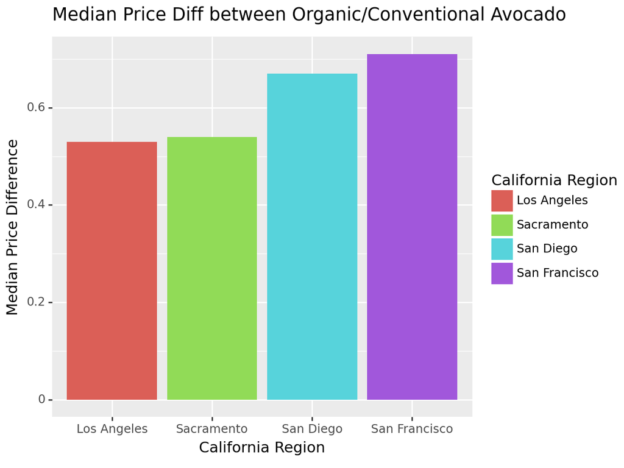

```
<Figure Size: (640 x 480)>
```

```python
(ggplot(avocado_median, aes(x='geography', y='price diff', fill='geography'))
+geom_bar(stat='identity')
+labs(x="California Region")
+labs(y="Median Price Difference")
+labs(fill = "California Region")
+ggtitle("Median Price Diff between Organic/Conventional Avocado"))
```

Again, San Francisco had the largest difference in medians between organic and conventional avocado prices. Overall based on the 3 summary statistics and visualizations, we can conclude that San Francisco has the largest price difference between organic and conventional avocados compared to the other California regions (Los Angeles, Sacramento, and San Diego). For the difference in average price for each type, San Francisco had the largest at 0.72. When looking at the difference in range for each type, San Francisco had the largest at 0.83. When looking at the median price difference by type, San Francisco had the largest at 0.71.

https://pandas.pydata.org/docs/reference/groupby.html

```python
#filter to only needed columns
avocado_cali_filtered = avocado_cali[["date", "geography", "type","Small_Hass_Sold", "Large_Hass_Sold", "Extra_Large_Hass_Sold"]]
avocado_cali_filtered
```

|  | date | geography | type | Small_Hass_Sold | Large_Hass_Sold | Extra_Large_Hass_Sold |
| --- | --- | --- | --- | --- | --- | --- |
| 44 | 2015-01-04 | Los Angeles | conventional | 1837999.65 | 524430.47 | 64225.78 |
| 45 | 2015-01-04 | Los Angeles | organic | 47721.51 | 1723.40 | 0.00 |
| 80 | 2015-01-04 | Sacramento | conventional | 110693.69 | 270107.61 | 9737.50 |
| 81 | 2015-01-04 | Sacramento | organic | 3727.52 | 4327.52 | 0.00 |
| 82 | 2015-01-04 | San Diego | conventional | 244152.26 | 165299.33 | 15302.75 |
| ... | ... | ... | ... | ... | ... | ... |
| 33018 | 2020-11-29 | Sacramento | organic | 3303.69 | 2057.03 | 0.00 |
| 33019 | 2020-11-29 | San Diego | conventional | 104509.99 | 19988.45 | 7210.47 |
| 33020 | 2020-11-29 | San Diego | organic | 894.63 | 838.11 | 0.00 |
| 33021 | 2020-11-29 | San Francisco | conventional | 128555.43 | 136718.24 | 5597.21 |
| 33022 | 2020-11-29 | San Francisco | organic | 2815.23 | 4542.30 | 0.00 |

2448 rows × 6 columns

```python
#create dataset for organic avocados
avocado_cali_organic = avocado_cali_filtered[avocado_cali_filtered['type'] == 'organic']
avocado_cali_organic
```

|  | date | geography | type | Small_Hass_Sold | Large_Hass_Sold | Extra_Large_Hass_Sold |
| --- | --- | --- | --- | --- | --- | --- |
| 45 | 2015-01-04 | Los Angeles | organic | 47721.51 | 1723.40 | 0.00 |
| 81 | 2015-01-04 | Sacramento | organic | 3727.52 | 4327.52 | 0.00 |
| 83 | 2015-01-04 | San Diego | organic | 17522.46 | 735.22 | 2.87 |
| 85 | 2015-01-04 | San Francisco | organic | 13175.57 | 9028.34 | 0.00 |
| 153 | 2015-01-11 | Los Angeles | organic | 52087.31 | 2063.44 | 0.00 |
| ... | ... | ... | ... | ... | ... | ... |
| 32914 | 2020-11-22 | San Francisco | organic | 3110.05 | 4956.81 | 4.17 |
| 32982 | 2020-11-29 | Los Angeles | organic | 6283.66 | 1658.88 | 4.65 |
| 33018 | 2020-11-29 | Sacramento | organic | 3303.69 | 2057.03 | 0.00 |
| 33020 | 2020-11-29 | San Diego | organic | 894.63 | 838.11 | 0.00 |
| 33022 | 2020-11-29 | San Francisco | organic | 2815.23 | 4542.30 | 0.00 |

1224 rows × 6 columns

```python
#create dataset for conventional avocados
avocado_cali_conventional = avocado_cali_filtered[avocado_cali_filtered['type'] == 'conventional']
avocado_cali_conventional
```

|  | date | geography | type | Small_Hass_Sold | Large_Hass_Sold | Extra_Large_Hass_Sold |
| --- | --- | --- | --- | --- | --- | --- |
| 44 | 2015-01-04 | Los Angeles | conventional | 1837999.65 | 524430.47 | 64225.78 |
| 80 | 2015-01-04 | Sacramento | conventional | 110693.69 | 270107.61 | 9737.50 |
| 82 | 2015-01-04 | San Diego | conventional | 244152.26 | 165299.33 | 15302.75 |
| 84 | 2015-01-04 | San Francisco | conventional | 179507.69 | 637000.10 | 8803.79 |
| 152 | 2015-01-11 | Los Angeles | conventional | 1786326.65 | 617233.39 | 58892.91 |
| ... | ... | ... | ... | ... | ... | ... |
| 32913 | 2020-11-22 | San Francisco | conventional | 156625.29 | 167370.28 | 4767.84 |
| 32981 | 2020-11-29 | Los Angeles | conventional | 848920.05 | 47467.30 | 77620.80 |
| 33017 | 2020-11-29 | Sacramento | conventional | 99656.68 | 131077.94 | 2792.36 |
| 33019 | 2020-11-29 | San Diego | conventional | 104509.99 | 19988.45 | 7210.47 |
| 33021 | 2020-11-29 | San Francisco | conventional | 128555.43 | 136718.24 | 5597.21 |

1224 rows × 6 columns

```python
#for organic avocados find the average of each size of Hass avocado sold by California region
avocado_cali_organic_gb = avocado_cali_organic[["geography", "Small_Hass_Sold", "Large_Hass_Sold", "Extra_Large_Hass_Sold"]].groupby(["geography"]).mean()
avocado_cali_organic_gb = avocado_cali_organic_gb.reset_index()

#total Hass avocado sold by region
avocado_cali_organic_gb["total"] = avocado_cali_organic_gb['Small_Hass_Sold'] + avocado_cali_organic_gb['Large_Hass_Sold'] + avocado_cali_organic_gb['Extra_Large_Hass_Sold']

#proportion of small Hass sold out of the total sold by region
avocado_cali_organic_gb["Small"] = (avocado_cali_organic_gb['Small_Hass_Sold']/avocado_cali_organic_gb['total'])*100

#proportion of large Hass sold out of the total sold by region
avocado_cali_organic_gb["Large"] = (avocado_cali_organic_gb['Large_Hass_Sold']/avocado_cali_organic_gb['total'])*100

#proportion of extra large Hass sold out of the total sold by region
avocado_cali_organic_gb["X-Large"] = (avocado_cali_organic_gb['Extra_Large_Hass_Sold']/avocado_cali_organic_gb['total'])*100

avocado_cali_organic_gb
```

|  | geography | Small_Hass_Sold | Large_Hass_Sold | Extra_Large_Hass_Sold | total | Small | Large | X-Large |
| --- | --- | --- | --- | --- | --- | --- | --- | --- |
| 0 | Los Angeles | 14442.064641 | 20804.220654 | 6.035294 | 35252.320588 | 40.967699 | 59.015181 | 0.017120 |
| 1 | Sacramento | 2808.892647 | 4282.693203 | 0.772680 | 7092.358529 | 39.604493 | 60.384612 | 0.010895 |
| 2 | San Diego | 2573.068268 | 7273.784575 | 1.323595 | 9848.176438 | 26.127358 | 73.859202 | 0.013440 |
| 3 | San Francisco | 8303.040784 | 11350.098072 | 2.159346 | 19655.298203 | 42.243270 | 57.745743 | 0.010986 |

```python
avocado_cali_organic_filtered = avocado_cali_organic_gb[["geography", "Small", "Large", "X-Large"]]

#add column so when merge, it is labeled organic
avocado_cali_organic_filtered["type"] = "organic"

#wide to long with a new column size for small/medium/large and values are the %
long_avocado_cali_organic = avocado_cali_organic_filtered.melt(id_vars = ['geography', 'type'], var_name = "Size", value_name = "%")
long_avocado_cali_organic
```

```
SettingWithCopyWarning:
A value is trying to be set on a copy of a slice from a DataFrame.
Try using .loc[row_indexer,col_indexer] = value instead

See the caveats in the documentation: https://pandas.pydata.org/pandas-docs/stable/user_guide/indexing.html#returning-a-view-versus-a-copy
```

|  | geography | type | Size | % |
| --- | --- | --- | --- | --- |
| 0 | Los Angeles | organic | Small | 40.967699 |
| 1 | Sacramento | organic | Small | 39.604493 |
| 2 | San Diego | organic | Small | 26.127358 |
| 3 | San Francisco | organic | Small | 42.243270 |
| 4 | Los Angeles | organic | Large | 59.015181 |
| 5 | Sacramento | organic | Large | 60.384612 |
| 6 | San Diego | organic | Large | 73.859202 |
| 7 | San Francisco | organic | Large | 57.745743 |
| 8 | Los Angeles | organic | X-Large | 0.017120 |
| 9 | Sacramento | organic | X-Large | 0.010895 |
| 10 | San Diego | organic | X-Large | 0.013440 |
| 11 | San Francisco | organic | X-Large | 0.010986 |

```python
#for conventional avocados find the average of each size of Hass avocado sold by California region
avocado_cali_conventional_gb = avocado_cali_conventional[["geography", "Small_Hass_Sold", "Large_Hass_Sold", "Extra_Large_Hass_Sold"]].groupby(["geography"]).mean()
avocado_cali_conventional_gb = avocado_cali_conventional_gb.reset_index()

#find total Hass avocado sold by California region
avocado_cali_conventional_gb["total"] = avocado_cali_conventional_gb['Small_Hass_Sold'] + avocado_cali_conventional_gb['Large_Hass_Sold'] + avocado_cali_conventional_gb['Extra_Large_Hass_Sold']

#proportion of small
avocado_cali_conventional_gb["Small"] = (avocado_cali_conventional_gb['Small_Hass_Sold']/avocado_cali_conventional_gb['total'])*100

#proportion of large
avocado_cali_conventional_gb["Large"] = (avocado_cali_conventional_gb['Large_Hass_Sold']/avocado_cali_conventional_gb['total'])*100

#proportion of extra large
avocado_cali_conventional_gb["X-Large"] = (avocado_cali_conventional_gb['Extra_Large_Hass_Sold']/avocado_cali_conventional_gb['total'])*100

avocado_cali_conventional_gb
```

|  | geography | Small_Hass_Sold | Large_Hass_Sold | Extra_Large_Hass_Sold | total | Small | Large | X-Large |
| --- | --- | --- | --- | --- | --- | --- | --- | --- |
| 0 | Los Angeles | 1.172952e+06 | 443842.308562 | 97073.643529 | 1.713868e+06 | 68.438884 | 25.897107 | 5.664008 |
| 1 | Sacramento | 1.412831e+05 | 243005.070163 | 6333.279673 | 3.906215e+05 | 36.168805 | 62.209861 | 1.621334 |
| 2 | San Diego | 1.637928e+05 | 140106.101438 | 17963.543497 | 3.218624e+05 | 50.889067 | 43.529809 | 5.581125 |
| 3 | San Francisco | 2.158398e+05 | 449377.420359 | 14931.603235 | 6.801488e+05 | 31.734197 | 66.070459 | 2.195344 |

```python
#take out columns we don't need
avocado_cali_conventional_filtered = avocado_cali_conventional_gb[["geography", "Small", "Large", "X-Large"]]

#add a column so when we merge, we know these are conventional avocados
avocado_cali_conventional_filtered["type"] = "conventional"

#wide to long creating a column size for the three % of small/medium/large, values are the % of total by region
long_avocado_cali_conventional= avocado_cali_conventional_filtered.melt(id_vars = ['geography', 'type'], var_name = "Size", value_name = "%")
long_avocado_cali_conventional
```

```
SettingWithCopyWarning:
A value is trying to be set on a copy of a slice from a DataFrame.
Try using .loc[row_indexer,col_indexer] = value instead

See the caveats in the documentation: https://pandas.pydata.org/pandas-docs/stable/user_guide/indexing.html#returning-a-view-versus-a-copy
```

|  | geography | type | Size | % |
| --- | --- | --- | --- | --- |
| 0 | Los Angeles | conventional | Small | 68.438884 |
| 1 | Sacramento | conventional | Small | 36.168805 |
| 2 | San Diego | conventional | Small | 50.889067 |
| 3 | San Francisco | conventional | Small | 31.734197 |
| 4 | Los Angeles | conventional | Large | 25.897107 |
| 5 | Sacramento | conventional | Large | 62.209861 |
| 6 | San Diego | conventional | Large | 43.529809 |
| 7 | San Francisco | conventional | Large | 66.070459 |
| 8 | Los Angeles | conventional | X-Large | 5.664008 |
| 9 | Sacramento | conventional | X-Large | 1.621334 |
| 10 | San Diego | conventional | X-Large | 5.581125 |
| 11 | San Francisco | conventional | X-Large | 2.195344 |

```python
#merge the two datasets together
avocado_pct = pd.concat([long_avocado_cali_organic, long_avocado_cali_conventional])
avocado_pct
```

|  | geography | type | Size | % |
| --- | --- | --- | --- | --- |
| 0 | Los Angeles | organic | Small | 40.967699 |
| 1 | Sacramento | organic | Small | 39.604493 |
| 2 | San Diego | organic | Small | 26.127358 |
| 3 | San Francisco | organic | Small | 42.243270 |
| 4 | Los Angeles | organic | Large | 59.015181 |
| 5 | Sacramento | organic | Large | 60.384612 |
| 6 | San Diego | organic | Large | 73.859202 |
| 7 | San Francisco | organic | Large | 57.745743 |
| 8 | Los Angeles | organic | X-Large | 0.017120 |
| 9 | Sacramento | organic | X-Large | 0.010895 |
| 10 | San Diego | organic | X-Large | 0.013440 |
| 11 | San Francisco | organic | X-Large | 0.010986 |
| 0 | Los Angeles | conventional | Small | 68.438884 |
| 1 | Sacramento | conventional | Small | 36.168805 |
| 2 | San Diego | conventional | Small | 50.889067 |
| 3 | San Francisco | conventional | Small | 31.734197 |
| 4 | Los Angeles | conventional | Large | 25.897107 |
| 5 | Sacramento | conventional | Large | 62.209861 |
| 6 | San Diego | conventional | Large | 43.529809 |
| 7 | San Francisco | conventional | Large | 66.070459 |
| 8 | Los Angeles | conventional | X-Large | 5.664008 |
| 9 | Sacramento | conventional | X-Large | 1.621334 |
| 10 | San Diego | conventional | X-Large | 5.581125 |
| 11 | San Francisco | conventional | X-Large | 2.195344 |

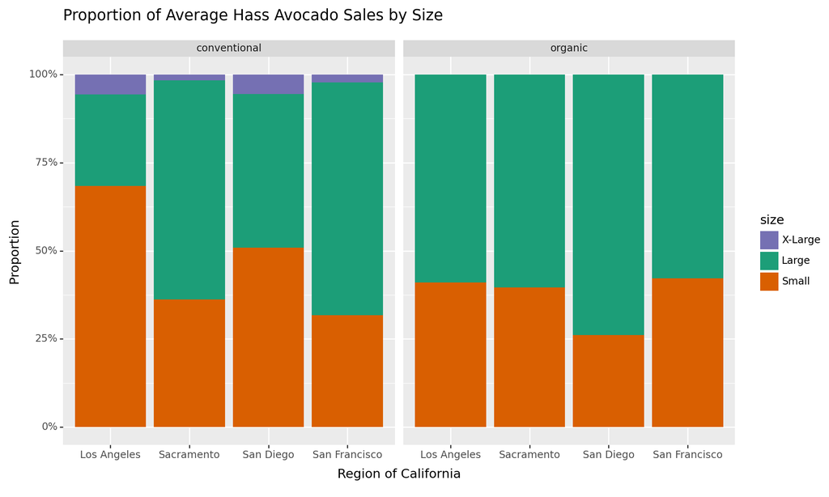

```
<Figure Size: (1000 x 600)>
```

```python
color_dict = {"X-Large":'#7570b3',
              "Large":'#1c9e78',
             "Small":'#d95f01'}

avocado_pct['Size'] = pd.Categorical(avocado_pct['Size'], categories=["X-Large", "Large", "Small"])


(ggplot(avocado_pct, aes(x='geography', y='%', fill = "Size"))
+geom_bar(stat = 'identity', position = 'stack')
+facet_wrap('type')
+labs(x="Region of California")
+labs(y="Proportion")
+labs(fill = "size")
+scale_y_continuous(breaks = [0,25,50,75,100], labels = ["0%", "25%", "50%", "75%", "100%"])
+scale_color_manual(values = color_dict)
+scale_fill_manual(values = color_dict)
+theme(figure_size=(10,6))
+ggtitle("Proportion of Average Hass Avocado Sales by Size"))
```

https://stackoverflow.com/questions/62507299/plotting-in-sorted-order-using-plotnine

## Using Outside Data

Find or make a data set with house prices for these four California regions. Join this data set with your California avocado data set.

Use your new joined data set to make an argument about the relationship between house prices and avocado prices/sales.

Support your argument with a plot.

https://www.fhfa.gov/DataTools/Downloads/Pages/House-Price-Index-Datasets.aspx

```python
house = pd.read_csv("C:/Users/alexa/OneDrive/Desktop/GSB544/HPI_Master.csv")
house
```

|  | hpi_type | hpi_flavor | frequency | level | place_name | place_id | yr | period | index_nsa | index_sa |
| --- | --- | --- | --- | --- | --- | --- | --- | --- | --- | --- |
| 0 | traditional | purchase-only | monthly | USA or Census Division | East North Central Division | DV_ENC | 1991 | 1 | 100.00 | 100.00 |
| 1 | traditional | purchase-only | monthly | USA or Census Division | East North Central Division | DV_ENC | 1991 | 2 | 100.91 | 100.97 |
| 2 | traditional | purchase-only | monthly | USA or Census Division | East North Central Division | DV_ENC | 1991 | 3 | 101.31 | 100.93 |
| 3 | traditional | purchase-only | monthly | USA or Census Division | East North Central Division | DV_ENC | 1991 | 4 | 101.70 | 100.99 |
| 4 | traditional | purchase-only | monthly | USA or Census Division | East North Central Division | DV_ENC | 1991 | 5 | 102.33 | 101.38 |
| ... | ... | ... | ... | ... | ... | ... | ... | ... | ... | ... |
| 123136 | developmental | purchase-only | quarterly | Puerto Rico | Puerto Rico | PR | 2022 | 2 | 182.17 | 181.09 |
| 123137 | developmental | purchase-only | quarterly | Puerto Rico | Puerto Rico | PR | 2022 | 3 | 200.25 | 195.51 |
| 123138 | developmental | purchase-only | quarterly | Puerto Rico | Puerto Rico | PR | 2022 | 4 | 193.50 | 195.67 |
| 123139 | developmental | purchase-only | quarterly | Puerto Rico | Puerto Rico | PR | 2023 | 1 | 190.07 | 194.24 |
| 123140 | developmental | purchase-only | quarterly | Puerto Rico | Puerto Rico | PR | 2023 | 2 | 209.59 | 209.20 |

123141 rows × 10 columns

```python
#only include necessary columns
house2 = house[["place_name", "yr", "period","index_nsa" ]]
house2
```

|  | place_name | yr | period | index_nsa |
| --- | --- | --- | --- | --- |
| 0 | East North Central Division | 1991 | 1 | 100.00 |
| 1 | East North Central Division | 1991 | 2 | 100.91 |
| 2 | East North Central Division | 1991 | 3 | 101.31 |
| 3 | East North Central Division | 1991 | 4 | 101.70 |
| 4 | East North Central Division | 1991 | 5 | 102.33 |
| ... | ... | ... | ... | ... |
| 123136 | Puerto Rico | 2022 | 2 | 182.17 |
| 123137 | Puerto Rico | 2022 | 3 | 200.25 |
| 123138 | Puerto Rico | 2022 | 4 | 193.50 |
| 123139 | Puerto Rico | 2023 | 1 | 190.07 |
| 123140 | Puerto Rico | 2023 | 2 | 209.59 |

123141 rows × 4 columns

```python
#only include these 4 California regions
filtered = (house2["place_name"] == "San Francisco-San Mateo-Redwood City, CA (MSAD)") | (house2["place_name"] == "San Diego-Chula Vista-Carlsbad, CA") |(house2["place_name"] =="Sacramento-Roseville-Folsom, CA")|(house2["place_name"] =="Los Angeles-Long Beach-Glendale, CA (MSAD)")

house_cali = house2[filtered]
house_cali

#map them so they have the same name to join on
house_cali["place_name"] = house_cali["place_name"].map({
    "Los Angeles-Long Beach-Glendale, CA (MSAD)": "Los Angeles",
    "San Francisco-San Mateo-Redwood City, CA (MSAD)":"San Francisco",
    "San Diego-Chula Vista-Carlsbad, CA":"San Diego",
    "Sacramento-Roseville-Folsom, CA":"Sacramento"
})

house_cali
```

```
SettingWithCopyWarning:
A value is trying to be set on a copy of a slice from a DataFrame.
Try using .loc[row_indexer,col_indexer] = value instead

See the caveats in the documentation: https://pandas.pydata.org/pandas-docs/stable/user_guide/indexing.html#returning-a-view-versus-a-copy
```

|  | place_name | yr | period | index_nsa |
| --- | --- | --- | --- | --- |
| 38480 | Los Angeles | 1975 | 1 | 20.44 |
| 38481 | Los Angeles | 1975 | 2 | 21.30 |
| 38482 | Los Angeles | 1975 | 3 | 21.50 |
| 38483 | Los Angeles | 1975 | 4 | 22.60 |
| 38484 | Los Angeles | 1976 | 1 | 23.96 |
| ... | ... | ... | ... | ... |
| 122653 | San Francisco | 2022 | 2 | 596.24 |
| 122654 | San Francisco | 2022 | 3 | 488.21 |
| 122655 | San Francisco | 2022 | 4 | 533.14 |
| 122656 | San Francisco | 2023 | 1 | 508.51 |
| 122657 | San Francisco | 2023 | 2 | 554.97 |

2196 rows × 4 columns

```python
#join the datasets, year and yr are equivalent and geography and place_name are equivalent
avo_house = avocado_cali.merge(house_cali, left_on=("year", "geography"), right_on=("yr", "place_name"))
avo_house
```

|  | date | average_price | total_volume | Small_Hass_Sold | Large_Hass_Sold | Extra_Large_Hass_Sold | total_bags | small_bags | large_bags | xlarge_bags | type | year | geography | Year | Month | Day | place_name | yr | period | index_nsa |
| --- | --- | --- | --- | --- | --- | --- | --- | --- | --- | --- | --- | --- | --- | --- | --- | --- | --- | --- | --- | --- |
| 0 | 2015-01-04 | 0.85 | 2682159.95 | 1837999.65 | 524430.47 | 64225.78 | 255504.05 | 215571.80 | 36981.72 | 2950.53 | conventional | 2015 | Los Angeles | 2015 | 01 | 04 | Los Angeles | 2015 | 1 | 282.77 |
| 1 | 2015-01-04 | 0.85 | 2682159.95 | 1837999.65 | 524430.47 | 64225.78 | 255504.05 | 215571.80 | 36981.72 | 2950.53 | conventional | 2015 | Los Angeles | 2015 | 01 | 04 | Los Angeles | 2015 | 2 | 287.87 |
| 2 | 2015-01-04 | 0.85 | 2682159.95 | 1837999.65 | 524430.47 | 64225.78 | 255504.05 | 215571.80 | 36981.72 | 2950.53 | conventional | 2015 | Los Angeles | 2015 | 01 | 04 | Los Angeles | 2015 | 3 | 294.63 |
| 3 | 2015-01-04 | 0.85 | 2682159.95 | 1837999.65 | 524430.47 | 64225.78 | 255504.05 | 215571.80 | 36981.72 | 2950.53 | conventional | 2015 | Los Angeles | 2015 | 01 | 04 | Los Angeles | 2015 | 4 | 299.13 |
| 4 | 2015-01-04 | 0.85 | 2682159.95 | 1837999.65 | 524430.47 | 64225.78 | 255504.05 | 215571.80 | 36981.72 | 2950.53 | conventional | 2015 | Los Angeles | 2015 | 01 | 04 | Los Angeles | 2015 | 1 | 220.75 |
| ... | ... | ... | ... | ... | ... | ... | ... | ... | ... | ... | ... | ... | ... | ... | ... | ... | ... | ... | ... | ... |
| 36715 | 2020-11-29 | 1.87 | 59527.02 | 2815.23 | 4542.30 | 0.00 | 52169.49 | 52034.33 | 135.16 | 0.00 | organic | 2020 | San Francisco | 2020 | 11 | 29 | San Francisco | 2020 | 4 | 482.15 |
| 36716 | 2020-11-29 | 1.87 | 59527.02 | 2815.23 | 4542.30 | 0.00 | 52169.49 | 52034.33 | 135.16 | 0.00 | organic | 2020 | San Francisco | 2020 | 11 | 29 | San Francisco | 2020 | 1 | 477.40 |
| 36717 | 2020-11-29 | 1.87 | 59527.02 | 2815.23 | 4542.30 | 0.00 | 52169.49 | 52034.33 | 135.16 | 0.00 | organic | 2020 | San Francisco | 2020 | 11 | 29 | San Francisco | 2020 | 2 | 483.60 |
| 36718 | 2020-11-29 | 1.87 | 59527.02 | 2815.23 | 4542.30 | 0.00 | 52169.49 | 52034.33 | 135.16 | 0.00 | organic | 2020 | San Francisco | 2020 | 11 | 29 | San Francisco | 2020 | 3 | 482.36 |
| 36719 | 2020-11-29 | 1.87 | 59527.02 | 2815.23 | 4542.30 | 0.00 | 52169.49 | 52034.33 | 135.16 | 0.00 | organic | 2020 | San Francisco | 2020 | 11 | 29 | San Francisco | 2020 | 4 | 478.21 |

36720 rows × 20 columns

```python
#relationship between house prices and avocado
avo_house2 = avo_house[["average_price", "total_volume", "type", "year", "geography", "index_nsa"]]
avo_house2
```

|  | average_price | total_volume | type | year | geography | index_nsa |
| --- | --- | --- | --- | --- | --- | --- |
| 0 | 0.85 | 2682159.95 | conventional | 2015 | Los Angeles | 282.77 |
| 1 | 0.85 | 2682159.95 | conventional | 2015 | Los Angeles | 287.87 |
| 2 | 0.85 | 2682159.95 | conventional | 2015 | Los Angeles | 294.63 |
| 3 | 0.85 | 2682159.95 | conventional | 2015 | Los Angeles | 299.13 |
| 4 | 0.85 | 2682159.95 | conventional | 2015 | Los Angeles | 220.75 |
| ... | ... | ... | ... | ... | ... | ... |
| 36715 | 1.87 | 59527.02 | organic | 2020 | San Francisco | 482.15 |
| 36716 | 1.87 | 59527.02 | organic | 2020 | San Francisco | 477.40 |
| 36717 | 1.87 | 59527.02 | organic | 2020 | San Francisco | 483.60 |
| 36718 | 1.87 | 59527.02 | organic | 2020 | San Francisco | 482.36 |
| 36719 | 1.87 | 59527.02 | organic | 2020 | San Francisco | 478.21 |

36720 rows × 6 columns

```python
#for each year, what is average price, total volume, and index_nsa
avo_house_year = avo_house2[["year","average_price", "total_volume", "index_nsa"]].groupby("year").mean()
avo_house_year = avo_house_year.reset_index()
avo_house_year
```

|  | year | average_price | total_volume | index_nsa |
| --- | --- | --- | --- | --- |
| 0 | 2015 | 1.370218 | 591634.933821 | 270.692500 |
| 1 | 2016 | 1.474635 | 644492.959782 | 292.207667 |
| 2 | 2017 | 1.668899 | 616204.505836 | 312.524500 |
| 3 | 2018 | 1.510313 | 670720.149306 | 336.511000 |
| 4 | 2019 | 1.605147 | 671174.872590 | 348.478333 |
| 5 | 2020 | 1.511076 | 788906.355979 | 365.848833 |

The house prices were the highest in 2020 and the highest average volume of avocados were sold per day. In 2015, the house prices were the lowest and the lowest volume of avocados were sold.

```python
#for each year and region, what is average price, total volume, and index_nsa
avo_house_year = avo_house2[["year","geography","average_price", "total_volume", "index_nsa"]].groupby(["year", "geography"]).mean()
avo_house_year = avo_house_year.reset_index()
avo_house_year
```

|  | year | geography | average_price | total_volume | index_nsa |
| --- | --- | --- | --- | --- | --- |
| 0 | 2015 | Los Angeles | 1.152500 | 1.425199e+06 | 249.623125 |
| 1 | 2015 | Sacramento | 1.454038 | 2.113513e+05 | 203.870833 |
| 2 | 2015 | San Diego | 1.274231 | 2.556320e+05 | 264.121875 |
| 3 | 2015 | San Francisco | 1.621058 | 3.792866e+05 | 348.448750 |
| 4 | 2016 | Los Angeles | 1.083750 | 1.568676e+06 | 267.760000 |
| 5 | 2016 | Sacramento | 1.668173 | 2.223368e+05 | 220.745833 |
| 6 | 2016 | San Diego | 1.313750 | 2.820966e+05 | 282.942500 |
| 7 | 2016 | San Francisco | 1.881250 | 3.993233e+05 | 379.516875 |
| 8 | 2017 | Los Angeles | 1.377358 | 1.495105e+06 | 288.755000 |
| 9 | 2017 | Sacramento | 1.774057 | 2.187965e+05 | 240.992500 |
| 10 | 2017 | San Diego | 1.584528 | 2.565499e+05 | 304.835625 |
| 11 | 2017 | San Francisco | 1.965943 | 3.950142e+05 | 397.631875 |
| 12 | 2018 | Los Angeles | 1.385000 | 1.540428e+06 | 307.420625 |
| 13 | 2018 | Sacramento | 1.498776 | 2.716389e+05 | 257.096667 |
| 14 | 2018 | San Diego | 1.509388 | 2.692326e+05 | 321.485000 |
| 15 | 2018 | San Francisco | 1.645204 | 5.018107e+05 | 440.188125 |
| 16 | 2019 | Los Angeles | 1.482019 | 1.568871e+06 | 320.026250 |
| 17 | 2019 | Sacramento | 1.593173 | 2.502340e+05 | 267.294167 |
| 18 | 2019 | San Diego | 1.582596 | 2.861347e+05 | 331.529375 |
| 19 | 2019 | San Francisco | 1.759808 | 4.742243e+05 | 454.767500 |
| 20 | 2020 | Los Angeles | 1.394896 | 1.826893e+06 | 342.659375 |
| 21 | 2020 | Sacramento | 1.504688 | 2.951080e+05 | 284.805833 |
| 22 | 2020 | San Diego | 1.474167 | 3.594122e+05 | 357.190000 |
| 23 | 2020 | San Francisco | 1.668958 | 5.507624e+05 | 458.479375 |

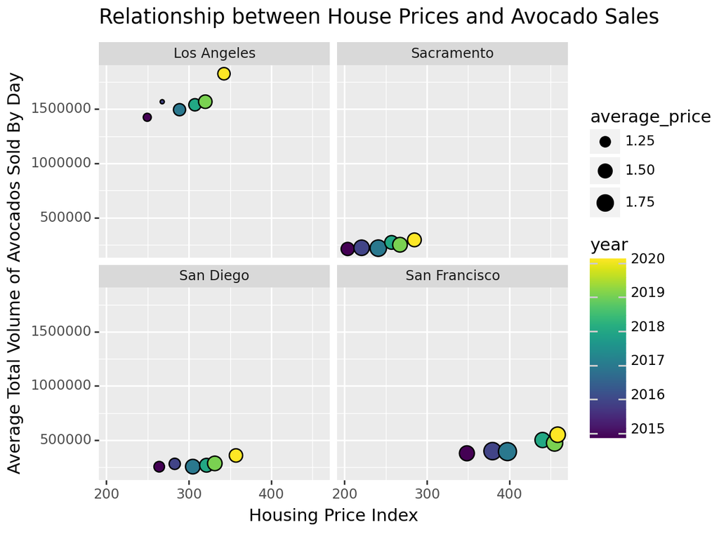

```
<Figure Size: (640 x 480)>
```

```python
(ggplot(avo_house_year, aes(x="index_nsa", y="total_volume", fill = "year"))
+geom_point(aes(size='average_price'))
+labs(x="Housing Price Index")
+labs(y="Average Total Volume of Avocados Sold By Day")
+facet_wrap("geography")
+ggtitle("Relationship between House Prices and Avocado Sales"))
```

In general as house prices increase based on the Housing Price Index, the average total volume of avocados sold per day overall also increases for Los Angeles, Sacramento, San Diego, and San Francisco. It increased the most in Los Angeles.

Overall, the claim that Millennials can’t buy houses because they spend their money on avocado toast is obviously outlandish. However, as housing prices continue to rise, the average number of avocados sold per day is also rising in the 4 California regions analyzed.